# STAT 183 Project

2024-05-09

## Loading data

```r
cvd <- read.csv("~/Desktop/UC_Riverside/2023-2024/Spring/STAT_183/Individual Project/CVD_cleaned.csv")
```

## Loading Libraries

```r
library(ggplot2)
library(dplyr)
# install.packages(gridExtra)
library(gridExtra) # Plots
library(tidyr)
library(MASS) # Stepwise Regression
library(car) # Multicollinearity (vif)
library(arm) # Binned Plotted Residuals
library(pROC) # Correlation Matrix
library(reshape2) # Correlation
```

# Glimpse of the data:

```r
glimpse(cvd)
```

```
## Rows: 308,854
## Columns: 19
## $ General_Health               <chr> "Poor", "Very Good", "Very Good", "Poor",…
## $ Checkup                      <chr> "Within the past 2 years", "Within the pa…
## $ Exercise                     <chr> "No", "No", "Yes", "Yes", "No", "No", "Ye…
## $ Heart_Disease                <chr> "No", "Yes", "No", "Yes", "No", "No", "Ye…
## $ Skin_Cancer                  <chr> "No", "No", "No", "No", "No", "No", "No",…
## $ Other_Cancer                 <chr> "No", "No", "No", "No", "No", "No", "No",…
## $ Depression                   <chr> "No", "No", "No", "No", "No", "Yes", "No"…
## $ Diabetes                     <chr> "No", "Yes", "Yes", "Yes", "No", "No", "N…
## $ Arthritis                    <chr> "Yes", "No", "No", "No", "No", "Yes", "Ye…
## $ Sex                          <chr> "Female", "Female", "Female", "Male", "Ma…
## $ Age_Category                 <chr> "70-74", "70-74", "60-64", "75-79", "80+"…
## $ Height_.cm.                  <dbl> 150, 165, 163, 180, 191, 183, 175, 165, 1…
## $ Weight_.kg.                  <dbl> 32.66, 77.11, 88.45, 93.44, 88.45, 154.22…
## $ BMI                          <dbl> 14.54, 28.29, 33.47, 28.73, 24.37, 46.11,…
## $ Smoking_History              <chr> "Yes", "No", "No", "No", "Yes", "No", "Ye…
## $ Alcohol_Consumption          <dbl> 0, 0, 4, 0, 0, 0, 0, 3, 0, 0, 0, 0, 8, 4,…
## $ Fruit_Consumption            <dbl> 30, 30, 12, 30, 8, 12, 16, 30, 12, 12, 30…
## $ Green_Vegetables_Consumption <dbl> 16, 0, 3, 30, 4, 12, 8, 8, 12, 12, 20, 8,…
## $ FriedPotato_Consumption      <dbl> 12, 4, 16, 8, 0, 12, 0, 8, 4, 1, 2, 30, 2…
```

# Summary Statistics

```r
summary(cvd)
```

```
##  General_Health       Checkup            Exercise         Heart_Disease
##  Length:308854      Length:308854      Length:308854      Length:308854
##  Class :character   Class :character   Class :character   Class :character
##  Mode  :character   Mode  :character   Mode  :character   Mode  :character
##
##
##
##  Skin_Cancer        Other_Cancer        Depression          Diabetes
##  Length:308854      Length:308854      Length:308854      Length:308854
##  Class :character   Class :character   Class :character   Class :character
##  Mode  :character   Mode  :character   Mode  :character   Mode  :character
##
##
##
##   Arthritis             Sex            Age_Category        Height_.cm.
##  Length:308854      Length:308854      Length:308854      Min.   : 91.0
##  Class :character   Class :character   Class :character   1st Qu.:163.0
##  Mode  :character   Mode  :character   Mode  :character   Median :170.0
##                                                           Mean   :170.6
##                                                           3rd Qu.:178.0
##                                                           Max.   :241.0
##   Weight_.kg.          BMI        Smoking_History    Alcohol_Consumption
##  Min.   : 24.95   Min.   :12.02   Length:308854      Min.   : 0.000
##  1st Qu.: 68.04   1st Qu.:24.21   Class :character   1st Qu.: 0.000
##  Median : 81.65   Median :27.44   Mode  :character   Median : 1.000
##  Mean   : 83.59   Mean   :28.63                      Mean   : 5.096
##  3rd Qu.: 95.25   3rd Qu.:31.85                      3rd Qu.: 6.000
##  Max.   :293.02   Max.   :99.33                      Max.   :30.000
##  Fruit_Consumption Green_Vegetables_Consumption FriedPotato_Consumption
##  Min.   :  0.00    Min.   :  0.00               Min.   :  0.000
##  1st Qu.: 12.00    1st Qu.:  4.00               1st Qu.:  2.000
##  Median : 30.00    Median : 12.00               Median :  4.000
##  Mean   : 29.84    Mean   : 15.11               Mean   :  6.297
##  3rd Qu.: 30.00    3rd Qu.: 20.00               3rd Qu.:  8.000
##  Max.   :120.00    Max.   :128.00               Max.   :128.000
```

## Variable classifications

```r
str(cvd)
```

```
## 'data.frame':    308854 obs. of  19 variables:
##  $ General_Health              : chr  "Poor" "Very Good" "Very Good" "Poor" ...
##  $ Checkup                     : chr  "Within the past 2 years" "Within the past year" "Within the past year" "Within the past year" ...
##  $ Exercise                    : chr  "No" "No" "Yes" "Yes" ...
##  $ Heart_Disease               : chr  "No" "Yes" "No" "Yes" ...
##  $ Skin_Cancer                 : chr  "No" "No" "No" "No" ...
##  $ Other_Cancer                : chr  "No" "No" "No" "No" ...
##  $ Depression                  : chr  "No" "No" "No" "No" ...
##  $ Diabetes                    : chr  "No" "Yes" "Yes" "Yes" ...
##  $ Arthritis                   : chr  "Yes" "No" "No" "No" ...
##  $ Sex                         : chr  "Female" "Female" "Female" "Male" ...
##  $ Age_Category                : chr  "70-74" "70-74" "60-64" "75-79" ...
##  $ Height_.cm.                 : num  150 165 163 180 191 183 175 165 163 163 ...
##  $ Weight_.kg.                 : num  32.7 77.1 88.5 93.4 88.5 ...
##  $ BMI                         : num  14.5 28.3 33.5 28.7 24.4 ...
##  $ Smoking_History             : chr  "Yes" "No" "No" "No" ...
##  $ Alcohol_Consumption         : num  0 0 4 0 0 0 0 3 0 0 ...
##  $ Fruit_Consumption           : num  30 30 12 30 8 12 16 30 12 12 ...
##  $ Green_Vegetables_Consumption: num  16 0 3 30 4 12 8 8 12 12 ...
##  $ FriedPotato_Consumption     : num  12 4 16 8 0 12 0 8 4 1 ...
```

# Data Cleaning:

- Remove any NA or duplicate observations

```r
# Checking for NA or Duplicates
sum(is.na(cvd))
```

```
## [1] 0
```

```r
sum(duplicated(cvd))
```

```
## [1] 80
```

- There are 80 duplicates, need to remove these observations

```r
cvd <- unique(cvd)
sum(duplicated(cvd))
```

```
## [1] 0
```

```r
glimpse(cvd)
```

```
## Rows: 308,774
## Columns: 19
## $ General_Health               <chr> "Poor", "Very Good", "Very Good", "Poor",…
## $ Checkup                      <chr> "Within the past 2 years", "Within the pa…
## $ Exercise                     <chr> "No", "No", "Yes", "Yes", "No", "No", "Ye…
## $ Heart_Disease                <chr> "No", "Yes", "No", "Yes", "No", "No", "Ye…
## $ Skin_Cancer                  <chr> "No", "No", "No", "No", "No", "No", "No",…
## $ Other_Cancer                 <chr> "No", "No", "No", "No", "No", "No", "No",…
## $ Depression                   <chr> "No", "No", "No", "No", "No", "Yes", "No"…
## $ Diabetes                     <chr> "No", "Yes", "Yes", "Yes", "No", "No", "N…
## $ Arthritis                    <chr> "Yes", "No", "No", "No", "No", "Yes", "Ye…
## $ Sex                          <chr> "Female", "Female", "Female", "Male", "Ma…
## $ Age_Category                 <chr> "70-74", "70-74", "60-64", "75-79", "80+"…
## $ Height_.cm.                  <dbl> 150, 165, 163, 180, 191, 183, 175, 165, 1…
## $ Weight_.kg.                  <dbl> 32.66, 77.11, 88.45, 93.44, 88.45, 154.22…
## $ BMI                          <dbl> 14.54, 28.29, 33.47, 28.73, 24.37, 46.11,…
## $ Smoking_History              <chr> "Yes", "No", "No", "No", "Yes", "No", "Ye…
## $ Alcohol_Consumption          <dbl> 0, 0, 4, 0, 0, 0, 0, 3, 0, 0, 0, 0, 8, 4,…
## $ Fruit_Consumption            <dbl> 30, 30, 12, 30, 8, 12, 16, 30, 12, 12, 30…
## $ Green_Vegetables_Consumption <dbl> 16, 0, 3, 30, 4, 12, 8, 8, 12, 12, 20, 8,…
## $ FriedPotato_Consumption      <dbl> 12, 4, 16, 8, 0, 12, 0, 8, 4, 1, 2, 30, 2…
```

- Changing Categorical variables to binary 0/1 integers
- Making factor levels for the predictor variables

```r
# Changing Character variables to Factors
# General Health
cvd$General_Health <- as.factor(cvd$General_Health)

# Checkup
cvd$Checkup <- as.factor(cvd$Checkup)

# Exercise
# n_distinct(cvd$Exercise) # 2
cvd$Exercise <- as.factor(cvd$Exercise)

# Heart Disease
n_distinct(cvd$Heart_Disease) # 2
```

```
## [1] 2
```

```r
cvd$HD_Int <- ifelse(cvd$Heart_Disease == "Yes", 1, 0)

# # Skin Cancer
# n_distinct(cvd$Skin_Cancer) # 2
cvd$Skin_Cancer <- as.factor(cvd$Skin_Cancer)
#
# # Other Cancer
# n_distinct(cvd$Other_Cancer) # 2
cvd$Other_Cancer <- as.factor(cvd$Other_Cancer)
#
# # Depression
# n_distinct(cvd$Depression) # 2
cvd$Depression <- as.factor(cvd$Depression)
#
# # Diabetes
# n_distinct(cvd$Diabetes) # 4
cvd$Diabetes <- as.factor(cvd$Diabetes)
#
# # Arthritis
# n_distinct(cvd$Arthritis)
cvd$Arthritis <- as.factor(cvd$Arthritis)
#
# # Sex
# n_distinct(cvd$Sex)
cvd$Sex <- as.factor(cvd$Sex)

# Age Category
cvd$Age_Category <- as.factor(cvd$Age_Category)

# Smoking History
cvd$Smoking_History <- as.factor(cvd$Smoking_History)

# head(cvd, 5)
str(cvd)
```

```
## 'data.frame':    308774 obs. of  20 variables:
##  $ General_Health              : Factor w/ 5 levels "Excellent","Fair",..: 4 5 5 4 3 3 2 3 2 2 ...
##  $ Checkup                     : Factor w/ 5 levels "5 or more years ago",..: 3 5 5 5 5 5 5 5 5 5 ...
##  $ Exercise                    : Factor w/ 2 levels "No","Yes": 1 1 2 2 1 1 2 2 1 1 ...
##  $ Heart_Disease               : chr  "No" "Yes" "No" "Yes" ...
##  $ Skin_Cancer                 : Factor w/ 2 levels "No","Yes": 1 1 1 1 1 1 1 1 1 1 ...
##  $ Other_Cancer                : Factor w/ 2 levels "No","Yes": 1 1 1 1 1 1 1 1 1 1 ...
##  $ Depression                  : Factor w/ 2 levels "No","Yes": 1 1 1 1 1 2 1 1 2 1 ...
##  $ Diabetes                    : Factor w/ 4 levels "No","No, pre-diabetes or borderline diabetes",..: 1 3 3 3 1 1 1 1 1 3 ...
##  $ Arthritis                   : Factor w/ 2 levels "No","Yes": 2 1 1 1 1 2 2 2 1 2 ...
##  $ Sex                         : Factor w/ 2 levels "Female","Male": 1 1 1 2 2 2 2 1 1 1 ...
##  $ Age_Category                : Factor w/ 13 levels "18-24","25-29",..: 11 11 9 12 13 9 9 10 10 11 ...
##  $ Height_.cm.                 : num  150 165 163 180 191 183 175 165 163 163 ...
##  $ Weight_.kg.                 : num  32.7 77.1 88.5 93.4 88.5 ...
##  $ BMI                         : num  14.5 28.3 33.5 28.7 24.4 ...
##  $ Smoking_History             : Factor w/ 2 levels "No","Yes": 2 1 1 1 2 1 2 2 2 1 ...
##  $ Alcohol_Consumption         : num  0 0 4 0 0 0 0 3 0 0 ...
##  $ Fruit_Consumption           : num  30 30 12 30 8 12 16 30 12 12 ...
##  $ Green_Vegetables_Consumption: num  16 0 3 30 4 12 8 8 12 12 ...
##  $ FriedPotato_Consumption     : num  12 4 16 8 0 12 0 8 4 1 ...
##  $ HD_Int                      : num  0 1 0 1 0 0 1 0 0 0 ...
```

# Exploratory Data Analysis (EDA)

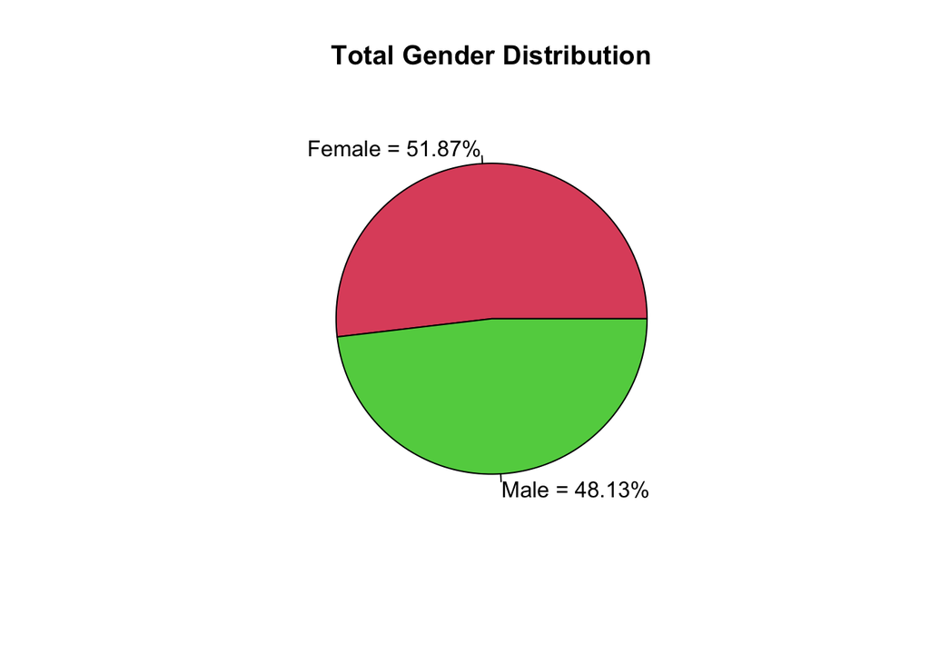

```r
# Gender Pie Chart for distribution
gender <- table(cvd$Sex)
gender_labels <- paste0(rownames(gender), " = ", round(100 * gender/sum(gender), 2), "%")

pie(gender, col = 2:3, labels = gender_labels, main = "Total Gender Distribution")
```

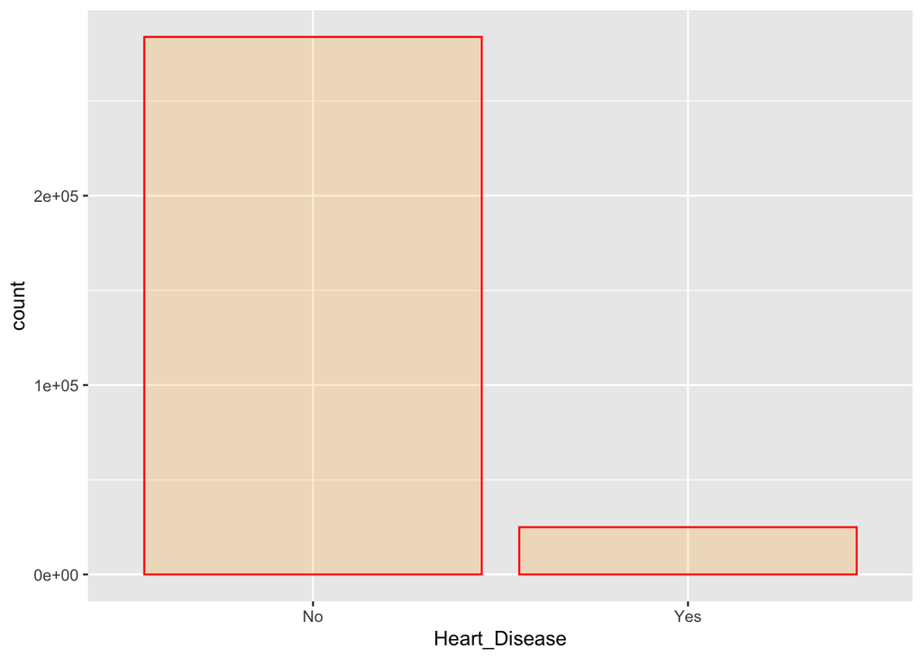

```r
ggplot(data = cvd, aes(x = Heart_Disease), fill = Sex) +
  geom_bar(color="red", fill="orange", alpha=0.2)
```

Based on this plot, we can see that a majority of the dataset contains people who do not have any history of heart disease.

- Distribution of Numerical Variables

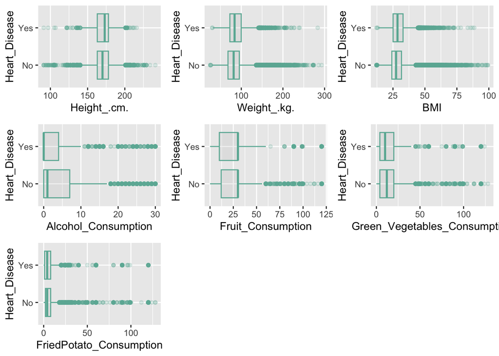

```r
pl1 <- ggplot(data = cvd, aes(x=Height_.cm., y=Heart_Disease)) +
  geom_boxplot(color="#69b3a2", fill="gray", alpha=0.2)

pl2 <- ggplot(data = cvd, aes(Weight_.kg., Heart_Disease)) +
  geom_boxplot(color="#69b3a2", fill="gray", alpha=0.2)

pl3 <- ggplot(data = cvd, aes(BMI, Heart_Disease)) +
  geom_boxplot(color="#69b3a2", fill="gray", alpha=0.2)

pl4 <- ggplot(data = cvd, aes(Alcohol_Consumption, Heart_Disease)) +
  geom_boxplot(color="#69b3a2", fill="gray", alpha=0.2)

pl5 <- ggplot(data = cvd, aes(Fruit_Consumption, Heart_Disease)) +
  geom_boxplot(color="#69b3a2", fill="gray", alpha=0.2)

pl6 <- ggplot(data = cvd, aes(Green_Vegetables_Consumption, Heart_Disease)) +
  geom_boxplot(color="#69b3a2", fill="gray", alpha=0.2)

pl7 <- ggplot(data = cvd, aes(FriedPotato_Consumption, Heart_Disease)) +
  geom_boxplot(color="#69b3a2", fill="gray", alpha=0.2)

grid.arrange(pl1,pl2,pl3,pl4,pl5,pl6,pl7)
```

- Distributions of Numerical Variables (Density Histograms)

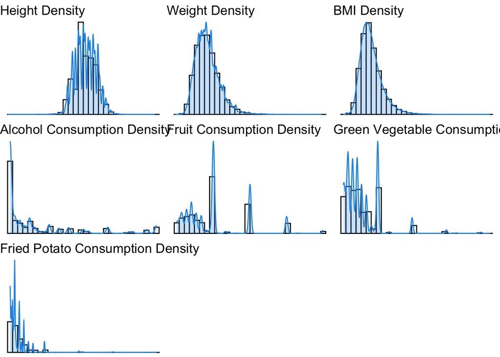

```r
pl1 <- ggplot(data = cvd, aes(x = Height_.cm., y = after_stat(density))) +
  geom_histogram(fill = "white", colour = "black") +
  geom_density(color = 4, fill = 4, alpha = 0.25) +
  ggtitle("Height Density") +
  xlab("Height (cm)") + ylab("Density") +
  theme_void()

pl2 <- ggplot(data = cvd, aes(x = Weight_.kg., y = after_stat(density))) +
  geom_histogram(fill = "white", colour = "black") +
  geom_density(color = 4, fill = 4, alpha = 0.25) +
  ggtitle("Weight Density") +
  xlab("Weight (kg)") + ylab("Density") +
  theme_void()

pl3 <- ggplot(data = cvd, aes(x = BMI, y = after_stat(density))) +
  geom_histogram(fill = "white", colour = "black") +
  geom_density(color = 4, fill = 4, alpha = 0.25) +
  ggtitle("BMI Density") +
  xlab("BMI") + ylab("Density") +
  theme_void()

pl4 <- ggplot(data = cvd, aes(x = Alcohol_Consumption, y = after_stat(density))) +
  geom_histogram(fill = "white", colour = "black") +
  geom_density(color = 4, fill = 4, alpha = 0.25) +
  ggtitle("Alcohol Consumption Density") +
  xlab("Number of Days Alcohol was Consumed within Last 30 Days") + ylab("Density") +
  theme_void()

pl5 <- ggplot(data = cvd, aes(x = Fruit_Consumption, y = after_stat(density))) +
  geom_histogram(fill = "white", colour = "black") +
  geom_density(color = 4, fill = 4, alpha = 0.25) +
  ggtitle("Fruit Consumption Density") +
  xlab("Fruit Consumption in last 30 days") + ylab("Density") +
  theme_void()

pl6 <- ggplot(data = cvd, aes(x = Green_Vegetables_Consumption, y = after_stat(density))) +
  geom_histogram(fill = "white", colour = "black") +
  geom_density(color = 4, fill = 4, alpha = 0.25) +
  ggtitle("Green Vegetable Consumption Density") +
  xlab("Green Vegetable Consumption in last 30 days") + ylab("Density") +
  theme_void()

pl7 <- ggplot(data = cvd, aes(x = FriedPotato_Consumption, y = after_stat(density))) +
  geom_histogram(fill = "white", colour = "black") +
  geom_density(color = 4, fill = 4, alpha = 0.25) +
  ggtitle("Fried Potato Consumption Density") +
  xlab("Fried Potato Consumption in last 30 days") + ylab("Density") +
  theme_void()

grid.arrange(pl1,pl2,pl3,pl4,pl5,pl6,pl7)
```

- Distributions of Categorical Variables

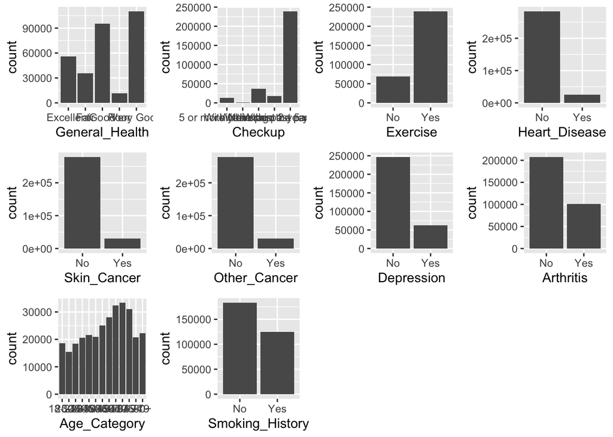

```r
pl1 <- ggplot(data = cvd, aes(x = General_Health)) +
  geom_bar()

pl2 <- ggplot(data = cvd, aes(x = Checkup)) +
  geom_bar()

pl3 <- ggplot(data = cvd, aes(x = Exercise)) +
  geom_bar()

pl4 <- ggplot(data = cvd, aes(x = Heart_Disease)) +
  geom_bar()

pl5 <- ggplot(data = cvd, aes(x = Skin_Cancer)) +
  geom_bar()

pl6 <- ggplot(data = cvd, aes(x = Other_Cancer)) +
  geom_bar()

pl7 <- ggplot(data = cvd, aes(x = Depression)) +
  geom_bar()

pl8 <- ggplot(data = cvd, aes(x = Arthritis)) +
  geom_bar()

pl9 <- ggplot(data = cvd, aes(x = Age_Category)) +
  geom_bar()

pl10 <- ggplot(data = cvd, aes(x = Smoking_History)) +
  geom_bar()

grid.arrange(pl1,pl2,pl3,pl4,pl5,pl6,pl7,pl8,pl9,pl10, ncol = 4)
```

```r
table(cvd$Heart_Disease)
```

```
##
##     No    Yes
## 283803  24971
```

Significantly more people without Heart Disease than with. Comparing 24,000s to 280,000s.

## Beginning Logistic Regression Modeling

```r
# Factor variables need to have at least 2 levels

model1 <- glm(formula = HD_Int ~ . - Heart_Disease, data = cvd, family = "binomial")
summary(model1)
```

```
##
## Call:
## glm(formula = HD_Int ~ . - Heart_Disease, family = "binomial",
##     data = cvd)
##
## Coefficients:
##                                                      Estimate Std. Error
## (Intercept)                                        -6.272e+00  4.939e-01
## General_HealthFair                                  1.707e+00  3.551e-02
## General_HealthGood                                  1.069e+00  3.362e-02
## General_HealthPoor                                  2.250e+00  3.995e-02
## General_HealthVery Good                             5.127e-01  3.443e-02
## CheckupNever                                        2.612e-01  1.531e-01
## CheckupWithin the past 2 years                      2.262e-01  6.353e-02
## CheckupWithin the past 5 years                      1.297e-01  7.485e-02
## CheckupWithin the past year                         5.235e-01  5.787e-02
## ExerciseYes                                        -1.805e-02  1.643e-02
## Skin_CancerYes                                      1.213e-01  1.975e-02
## Other_CancerYes                                     4.802e-02  1.945e-02
## DepressionYes                                       2.448e-01  1.812e-02
## DiabetesNo, pre-diabetes or borderline diabetes     1.462e-01  4.120e-02
## DiabetesYes                                         5.333e-01  1.695e-02
## DiabetesYes, but female told only during pregnancy  1.292e-01  1.091e-01
## ArthritisYes                                        2.606e-01  1.534e-02
## SexMale                                             8.324e-01  2.098e-02
## Age_Category25-29                                   3.063e-01  1.404e-01
## Age_Category30-34                                   6.373e-01  1.259e-01
## Age_Category35-39                                   7.547e-01  1.206e-01
## Age_Category40-44                                   1.085e+00  1.149e-01
## Age_Category45-49                                   1.463e+00  1.114e-01
## Age_Category50-54                                   1.777e+00  1.085e-01
## Age_Category55-59                                   2.116e+00  1.069e-01
## Age_Category60-64                                   2.356e+00  1.062e-01
## Age_Category65-69                                   2.598e+00  1.059e-01
## Age_Category70-74                                   2.858e+00  1.059e-01
## Age_Category75-79                                   3.097e+00  1.064e-01
## Age_Category80+                                     3.373e+00  1.062e-01
## Height_.cm.                                        -5.191e-03  2.827e-03
## Weight_.kg.                                         3.153e-04  2.564e-03
## BMI                                                 8.352e-04  7.401e-03
```

[output cut: 39 more lines]

```
## Smoking_HistoryYes                                  26.735  < 2e-16 ***
## Alcohol_Consumption                                -10.782  < 2e-16 ***
## Fruit_Consumption                                    0.102 0.918677
## Green_Vegetables_Consumption                         1.508 0.131636
## FriedPotato_Consumption                             -0.704 0.481547
## ---
## Signif. codes:  0 '***' 0.001 '**' 0.01 '*' 0.05 '.' 0.1 ' ' 1
##
## (Dispersion parameter for binomial family taken to be 1)
##
##     Null deviance: 173465  on 308773  degrees of freedom
## Residual deviance: 136957  on 308736  degrees of freedom
## AIC: 137033
##
## Number of Fisher Scoring iterations: 7
```

- Contains all 18 predictor variables.

## Wald test on predictors that have at least one level where p-value > alpha

```r
# Wald Test on Checkup
model <- glm(HD_Int ~ Checkup, data = cvd, family = binomial)
Anova(model, type = "II", test = "Wald")
```

```
## Analysis of Deviance Table (Type II tests)
##
## Response: HD_Int
##         Df Chisq Pr(>Chisq)
## Checkup  4  2460  < 2.2e-16 ***
## ---
## Signif. codes:  0 '***' 0.001 '**' 0.01 '*' 0.05 '.' 0.1 ' ' 1
```

```r
cat("----------------------------------------------------------------------------------", "\n")
# Wald Test on Diabetes
model <- glm(HD_Int ~ Diabetes, data = cvd, family = binomial)
Anova(model, type = "II", test = "Wald")
```

```
## Analysis of Deviance Table (Type II tests)
##
## Response: HD_Int
##          Df  Chisq Pr(>Chisq)
## Diabetes  3 9187.5  < 2.2e-16 ***
## ---
## Signif. codes:  0 '***' 0.001 '**' 0.01 '*' 0.05 '.' 0.1 ' ' 1
```

- Overall P-Values for both Checkup and Diabetes are small, so we can conclude they are significant to the model.

Wald test on Exercise

```r
# Wald Test on Diabetes
model <- glm(HD_Int ~ Exercise, data = cvd, family = binomial)
Anova(model, type = "II", test = "Wald")
```

```
## Analysis of Deviance Table (Type II tests)
##
## Response: HD_Int
##          Df  Chisq Pr(>Chisq)
## Exercise  1 2765.3  < 2.2e-16 ***
## ---
## Signif. codes:  0 '***' 0.001 '**' 0.01 '*' 0.05 '.' 0.1 ' ' 1
```

## ANOVA

```r
anova <- aov(model1)
summary(anova)
```

```
##                                  Df Sum Sq Mean Sq  F value   Pr(>F)
## General_Health                    4   1429   357.3 5497.475  < 2e-16 ***
## Checkup                           4    119    29.7  456.776  < 2e-16 ***
## Exercise                          1     14    14.0  215.936  < 2e-16 ***
## Skin_Cancer                       1    128   127.9 1968.513  < 2e-16 ***
## Other_Cancer                      1     36    36.3  558.612  < 2e-16 ***
## Depression                        1      8     8.2  126.209  < 2e-16 ***
## Diabetes                          3    268    89.4 1375.067  < 2e-16 ***
## Arthritis                         1    106   105.7 1627.085  < 2e-16 ***
## Sex                               1    164   163.7 2519.636  < 2e-16 ***
## Age_Category                     12    559    46.6  716.544  < 2e-16 ***
## Height_.cm.                       1      1     0.9   14.016 0.000181 ***
## Weight_.kg.                       1      1     1.5   23.032 1.59e-06 ***
## BMI                               1      0     0.1    0.877 0.348892
## Smoking_History                   1     44    44.0  677.229  < 2e-16 ***
## Alcohol_Consumption               1     10     9.8  150.987  < 2e-16 ***
## Fruit_Consumption                 1      0     0.0    0.653 0.418894
## Green_Vegetables_Consumption      1      0     0.2    2.889 0.089176 .
## FriedPotato_Consumption           1      0     0.1    0.841 0.359101
## Residuals                    308736  20064     0.1
## ---
## Signif. codes:  0 '***' 0.001 '**' 0.01 '*' 0.05 '.' 0.1 ' ' 1
```

Binned Residuals Plot

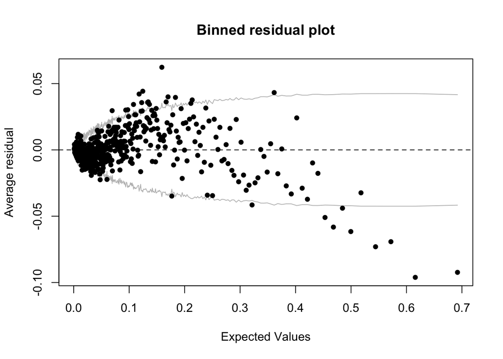

```r
binnedplot(fitted(model1),
           residuals(model1, type = "response"),
           nclass = NULL,
           xlab = "Expected Values",
           ylab = "Average residual",
           main = "Binned residual plot",
           cex.pts = 0.8,
           col.pts = 1,
           col.int = "gray")
```

## Accuracy of Full Model

```r
prediction <- ifelse(model1$fitted.values > 0.5, "pos", "neg")

confusion_matrix <- table(cvd$HD_Int, prediction)
rownames(confusion_matrix) <- c("No Heart Disease", "Heart Disease")
colnames(confusion_matrix) <- c("Predicted No Heart Disease", "Predicted Heart Disease")
confusion_matrix
```

```
##                   prediction
##                    Predicted No Heart Disease Predicted Heart Disease
##   No Heart Disease                     282311                    1492
##   Heart Disease                         23418                    1553
```

```r
accuracy <- sum(diag(confusion_matrix))/sum(confusion_matrix)
accuracy
```

```
## [1] 0.9193261
```

```r
# Area under curve, 1 indicates perfect predictive model
auc(cvd$HD_Int~model1$fitted.values, data = cvd)
```

```
## Area under the curve: 0.8351
```

## Multicollinearity Analysis

```r
vif(model1)
```

```
##                                   GVIF Df GVIF^(1/(2*Df))
## General_Health                1.293889  4        1.032731
## Checkup                       1.063265  4        1.007698
## Exercise                      1.171483  1        1.082351
## Skin_Cancer                   1.085002  1        1.041634
## Other_Cancer                  1.059698  1        1.029416
## Depression                    1.147095  1        1.071025
## Diabetes                      1.155402  3        1.024367
## Arthritis                     1.137940  1        1.066743
## Sex                           2.095054  1        1.447430
## Age_Category                  1.366381 12        1.013092
## Height_.cm.                  17.958276  1        4.237721
## Weight_.kg.                  61.822837  1        7.862750
## BMI                          48.305413  1        6.950210
## Smoking_History               1.054379  1        1.026830
## Alcohol_Consumption           1.079800  1        1.039134
## Fruit_Consumption             1.104466  1        1.050936
## Green_Vegetables_Consumption  1.100718  1        1.049151
## FriedPotato_Consumption       1.036166  1        1.017922
```

- By squaring the GVIF^(1/(2*Df)) values, we can conclude that there is a high multicollinearity problem regarding Height, Weight, and BMI.
- Reduced_model1 is removing Heart_Disease, Height, Weight, and BMI

```r
# Reduced model after VIF

reduced_model1 <- glm(formula = HD_Int ~ . - Heart_Disease - Height_.cm. - Weight_.kg. - BMI, data = cvd, family = "binomial")
summary(reduced_model1)
```

```
##
## Call:
## glm(formula = HD_Int ~ . - Heart_Disease - Height_.cm. - Weight_.kg. -
##     BMI, family = "binomial", data = cvd)
##
## Coefficients:
##                                                      Estimate Std. Error
## (Intercept)                                        -7.079e+00  1.227e-01
## General_HealthFair                                  1.715e+00  3.540e-02
## General_HealthGood                                  1.076e+00  3.353e-02
## General_HealthPoor                                  2.258e+00  3.989e-02
## General_HealthVery Good                             5.149e-01  3.440e-02
## CheckupNever                                        2.702e-01  1.530e-01
## CheckupWithin the past 2 years                      2.282e-01  6.352e-02
## CheckupWithin the past 5 years                      1.308e-01  7.485e-02
## CheckupWithin the past year                         5.265e-01  5.784e-02
## ExerciseYes                                        -2.223e-02  1.635e-02
## Skin_CancerYes                                      1.167e-01  1.973e-02
## Other_CancerYes                                     4.609e-02  1.945e-02
## DepressionYes                                       2.458e-01  1.811e-02
## DiabetesNo, pre-diabetes or borderline diabetes     1.535e-01  4.111e-02
## DiabetesYes                                         5.380e-01  1.664e-02
## DiabetesYes, but female told only during pregnancy  1.343e-01  1.091e-01
## ArthritisYes                                        2.626e-01  1.523e-02
## SexMale                                             7.601e-01  1.541e-02
## Age_Category25-29                                   3.113e-01  1.404e-01
## Age_Category30-34                                   6.429e-01  1.258e-01
## Age_Category35-39                                   7.612e-01  1.205e-01
## Age_Category40-44                                   1.092e+00  1.148e-01
## Age_Category45-49                                   1.470e+00  1.113e-01
## Age_Category50-54                                   1.785e+00  1.084e-01
## Age_Category55-59                                   2.124e+00  1.069e-01
## Age_Category60-64                                   2.363e+00  1.062e-01
## Age_Category65-69                                   2.606e+00  1.059e-01
## Age_Category70-74                                   2.868e+00  1.059e-01
## Age_Category75-79                                   3.109e+00  1.064e-01
## Age_Category80+                                     3.386e+00  1.061e-01
## Smoking_HistoryYes                                  3.931e-01  1.478e-02
## Alcohol_Consumption                                -1.006e-02  9.129e-04
## Fruit_Consumption                                   7.103e-06  3.105e-04
```

[output cut: 33 more lines]

```
## Smoking_HistoryYes                                  26.593  < 2e-16 ***
## Alcohol_Consumption                                -11.022  < 2e-16 ***
## Fruit_Consumption                                    0.023 0.981750
## Green_Vegetables_Consumption                         1.427 0.153487
## FriedPotato_Consumption                             -0.783 0.433863
## ---
## Signif. codes:  0 '***' 0.001 '**' 0.01 '*' 0.05 '.' 0.1 ' ' 1
##
## (Dispersion parameter for binomial family taken to be 1)
##
##     Null deviance: 173465  on 308773  degrees of freedom
## Residual deviance: 136986  on 308739  degrees of freedom
## AIC: 137056
##
## Number of Fisher Scoring iterations: 7
```

```r
vif(reduced_model1)
```

```
##                                  GVIF Df GVIF^(1/(2*Df))
## General_Health               1.281180  4        1.031457
## Checkup                      1.060951  4        1.007423
## Exercise                     1.159146  1        1.076637
## Skin_Cancer                  1.082643  1        1.040501
## Other_Cancer                 1.058826  1        1.028993
## Depression                   1.145372  1        1.070221
## Diabetes                     1.111833  3        1.017825
## Arthritis                    1.121720  1        1.059113
## Sex                          1.130849  1        1.063414
## Age_Category                 1.269022 12        1.009976
## Smoking_History              1.051306  1        1.025332
## Alcohol_Consumption          1.076278  1        1.037438
## Fruit_Consumption            1.104214  1        1.050816
## Green_Vegetables_Consumption 1.100307  1        1.048955
## FriedPotato_Consumption      1.035179  1        1.017437
```

- No sign of multicollinearity.
- Results in 15 variables.

Binned Residuals Plot

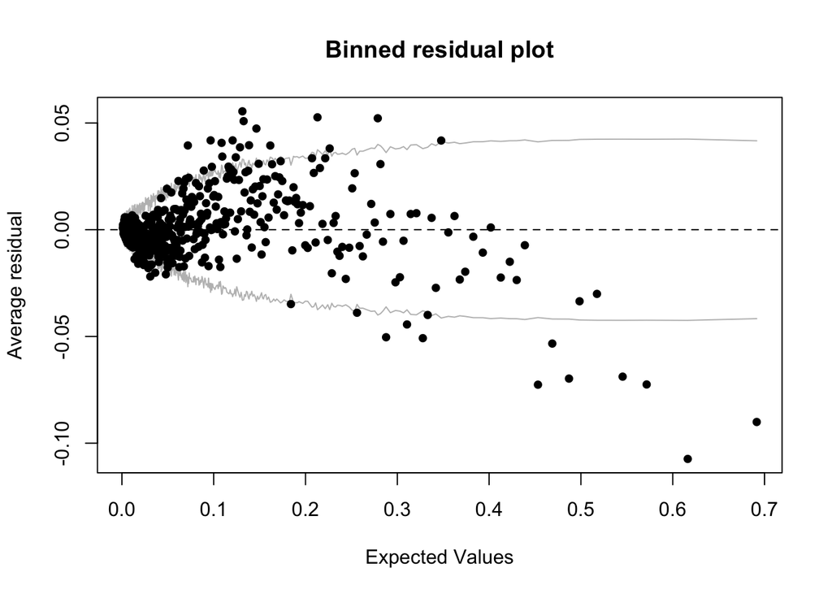

```r
binnedplot(fitted(reduced_model1),
           residuals(reduced_model1, type = "response"),
           nclass = NULL,
           xlab = "Expected Values",
           ylab = "Average residual",
           main = "Binned residual plot",
           cex.pts = 0.8,
           col.pts = 1,
           col.int = "gray")
```

- Visually, lots of outliers exist.
- Outliers can be caused by some unknown outside factors.

## ANOVA

```r
anova <- aov(reduced_model1)
summary(anova)
```

```
##                                  Df Sum Sq Mean Sq  F value Pr(>F)
## General_Health                    4   1429   357.3 5496.895 <2e-16 ***
## Checkup                           4    119    29.7  456.728 <2e-16 ***
## Exercise                          1     14    14.0  215.914 <2e-16 ***
## Skin_Cancer                       1    128   127.9 1968.306 <2e-16 ***
## Other_Cancer                      1     36    36.3  558.553 <2e-16 ***
## Depression                        1      8     8.2  126.195 <2e-16 ***
## Diabetes                          3    268    89.4 1374.922 <2e-16 ***
## Arthritis                         1    106   105.7 1626.913 <2e-16 ***
## Sex                               1    164   163.7 2519.370 <2e-16 ***
## Age_Category                     12    559    46.6  716.469 <2e-16 ***
## Smoking_History                   1     44    44.3  681.413 <2e-16 ***
## Alcohol_Consumption               1     10     9.6  148.111 <2e-16 ***
## Fruit_Consumption                 1      0     0.1    0.847 0.3573
## Green_Vegetables_Consumption      1      0     0.2    3.163 0.0753 .
## FriedPotato_Consumption           1      0     0.1    1.326 0.2495
## Residuals                    308739  20067     0.1
## ---
## Signif. codes:  0 '***' 0.001 '**' 0.01 '*' 0.05 '.' 0.1 ' ' 1
```

## Accuracy of Reduced Model 1

```r
prediction <- ifelse(reduced_model1$fitted.values > 0.5, "pos", "neg")
#
confusion_matrix <- table(cvd$HD_Int, prediction)
rownames(confusion_matrix) <- c("No Heart Disease", "Heart Disease")
colnames(confusion_matrix) <- c("Predicted No Heart Disease", "Predicted Heart Disease")
confusion_matrix
```

```
##                   prediction
##                    Predicted No Heart Disease Predicted Heart Disease
##   No Heart Disease                     282350                    1453
##   Heart Disease                         23438                    1533
```

```r
accuracy <- sum(diag(confusion_matrix))/sum(confusion_matrix)
accuracy
```

```
## [1] 0.9193876
```

```r
# Area under curve, 1 indicates perfect predictive model
auc(cvd$HD_Int~reduced_model1$fitted.values, data = cvd)
```

```
## Area under the curve: 0.835
```

## Stepwise Regression Model

- Performs stepwise regression on the full model

```r
model2 <- stepAIC(model1, direction = "both", trace = F) # On full model
summary(model2)
```

```
##
## Call:
## glm(formula = HD_Int ~ General_Health + Checkup + Skin_Cancer +
##     Other_Cancer + Depression + Diabetes + Arthritis + Sex +
##     Age_Category + Height_.cm. + Weight_.kg. + Smoking_History +
##     Alcohol_Consumption + Green_Vegetables_Consumption, family = "binomial",
##     data = cvd)
##
## Coefficients:
##                                                      Estimate Std. Error
## (Intercept)                                        -6.2311969  0.2005056
## General_HealthFair                                  1.7096980  0.0352880
## General_HealthGood                                  1.0702314  0.0335476
## General_HealthPoor                                  2.2560762  0.0394223
## General_HealthVery Good                             0.5123969  0.0344188
## CheckupNever                                        0.2623874  0.1530742
## CheckupWithin the past 2 years                      0.2260931  0.0635142
## CheckupWithin the past 5 years                      0.1293801  0.0748481
## CheckupWithin the past year                         0.5234075  0.0578510
## Skin_CancerYes                                      0.1207921  0.0197426
## Other_CancerYes                                     0.0479837  0.0194509
## DepressionYes                                       0.2456192  0.0181038
## DiabetesNo, pre-diabetes or borderline diabetes     0.1462278  0.0412005
## DiabetesYes                                         0.5340382  0.0169280
## DiabetesYes, but female told only during pregnancy  0.1283153  0.1091454
## ArthritisYes                                        0.2607693  0.0153372
## SexMale                                             0.8303160  0.0208292
## Age_Category25-29                                   0.3065668  0.1404123
## Age_Category30-34                                   0.6379956  0.1258801
## Age_Category35-39                                   0.7555672  0.1205478
## Age_Category40-44                                   1.0867726  0.1149207
## Age_Category45-49                                   1.4656747  0.1113442
## Age_Category50-54                                   1.7798942  0.1084610
## Age_Category55-59                                   2.1195917  0.1068943
## Age_Category60-64                                   2.3592314  0.1061230
## Age_Category65-69                                   2.6013223  0.1058589
## Age_Category70-74                                   2.8618893  0.1058114
## Age_Category75-79                                   3.1015121  0.1063255
## Age_Category80+                                     3.3787104  0.1060891
## Height_.cm.                                        -0.0055565  0.0010177
```

[output cut: 34 more lines]

```
## Height_.cm.                                         -5.460 4.77e-08 ***
## Weight_.kg.                                          1.597 0.110351
## Smoking_HistoryYes                                  26.862  < 2e-16 ***
## Alcohol_Consumption                                -10.832  < 2e-16 ***
## Green_Vegetables_Consumption                         1.445 0.148370
## ---
## Signif. codes:  0 '***' 0.001 '**' 0.01 '*' 0.05 '.' 0.1 ' ' 1
##
## (Dispersion parameter for binomial family taken to be 1)
##
##     Null deviance: 173465  on 308773  degrees of freedom
## Residual deviance: 136959  on 308740  degrees of freedom
## AIC: 137027
##
## Number of Fisher Scoring iterations: 7
```

- Lowered AIC from full model 137033 to 137027.
- This model only contains 14 variables: General_Health, Checkup, Skin_Cancer, Other_Cancer, Depression, Diabetes, Arthritis, Sex, Age_Category, Height_.cm., Weight_.kg., Smoking_History, Alcohol_Consumption, Green_Vegetables_Consumption

ANOVA of Stepwise Model

```r
anova <- aov(model2)
summary(anova)
```

```
##                                  Df Sum Sq Mean Sq  F value   Pr(>F)
## General_Health                    4   1429   357.3 5497.361  < 2e-16 ***
## Checkup                           4    119    29.7  456.767  < 2e-16 ***
## Skin_Cancer                       1    127   127.1 1955.380  < 2e-16 ***
## Other_Cancer                      1     37    36.9  567.510  < 2e-16 ***
## Depression                        1      8     7.6  117.540  < 2e-16 ***
## Diabetes                          3    276    91.9 1413.357  < 2e-16 ***
## Arthritis                         1    108   108.2 1664.915  < 2e-16 ***
## Sex                               1    160   160.3 2466.710  < 2e-16 ***
## Age_Category                     12    566    47.2  725.694  < 2e-16 ***
## Height_.cm.                       1      1     1.0   15.338 8.99e-05 ***
## Weight_.kg.                       1      1     1.2   19.167 1.20e-05 ***
## Smoking_History                   1     45    44.7  687.230  < 2e-16 ***
## Alcohol_Consumption               1     10    10.1  154.808  < 2e-16 ***
## Green_Vegetables_Consumption      1      0     0.2    2.468    0.116
## Residuals                    308740  20065     0.1
## ---
## Signif. codes:  0 '***' 0.001 '**' 0.01 '*' 0.05 '.' 0.1 ' ' 1
```

Binned Residuals Plot

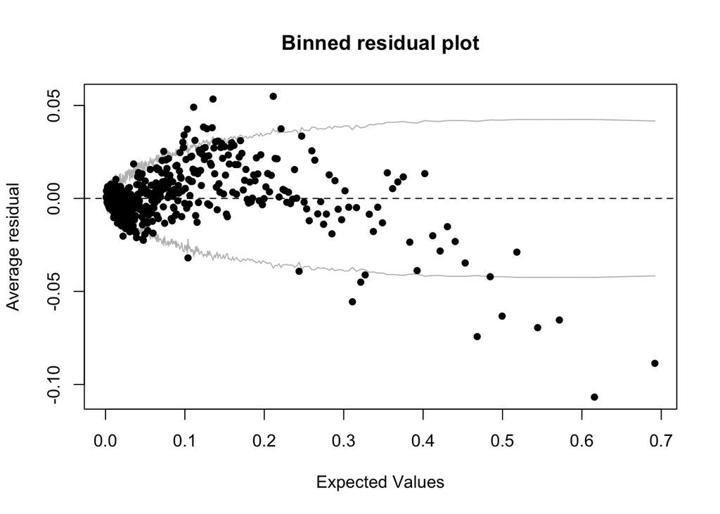

```r
binnedplot(fitted(model2),
           residuals(model2, type = "response"),
           nclass = NULL,
           xlab = "Expected Values",
           ylab = "Average residual",
           main = "Binned residual plot",
           cex.pts = 0.8,
           col.pts = 1,
           col.int = "gray")
```

- Visually, lots of outliers exist.
- Outliers can be caused by some unknown outside factors.

## Accuracy of Stepwise Model

```r
prediction <- ifelse(model2$fitted.values > 0.5, "pos", "neg")

confusion_matrix <- table(cvd$HD_Int, prediction)
rownames(confusion_matrix) <- c("No Heart Disease", "Heart Disease")
colnames(confusion_matrix) <- c("Predicted No Heart Disease", "Predicted Heart Disease")
confusion_matrix
```

```
##                   prediction
##                    Predicted No Heart Disease Predicted Heart Disease
##   No Heart Disease                     282317                    1486
##   Heart Disease                         23417                    1554
```

```r
accuracy <- sum(diag(confusion_matrix))/sum(confusion_matrix)
accuracy
```

```
## [1] 0.9193488
```

```r
# Area under curve, 1 indicates perfect predictive model
auc(cvd$HD_Int~model2$fitted.values, data = cvd)
```

```
## Area under the curve: 0.8351
```

```r
vif(model2)
```

```
##                                  GVIF Df GVIF^(1/(2*Df))
## General_Health               1.216653  4        1.024816
## Checkup                      1.062218  4        1.007573
## Skin_Cancer                  1.083744  1        1.041030
## Other_Cancer                 1.059274  1        1.029210
## Depression                   1.144614  1        1.069866
## Diabetes                     1.152001  3        1.023864
## Arthritis                    1.137527  1        1.066549
## Sex                          2.064662  1        1.436893
## Age_Category                 1.339493 12        1.012253
## Height_.cm.                  2.326569  1        1.525310
## Weight_.kg.                  1.502236  1        1.225657
## Smoking_History              1.046645  1        1.023057
## Alcohol_Consumption          1.077918  1        1.038228
## Green_Vegetables_Consumption 1.025018  1        1.012432
```

- No sign of multicollinearity.

## Log Transform Data

- Caution, with the log transformation, now it’s possible to obtain -Infinity values because we have zero values in our numerical data
- Going to shift the data so that values can stay positive

```r
new_cvd <- cvd
new_cvd$Alcohol_Consumption <- new_cvd$Alcohol_Consumption + 1
new_cvd$Fruit_Consumption <- new_cvd$Fruit_Consumption + 1
new_cvd$Green_Vegetables_Consumption <- new_cvd$Green_Vegetables_Consumption + 1
new_cvd$FriedPotato_Consumption <- new_cvd$FriedPotato_Consumption + 1
new_cvd$HD_Int <- new_cvd$HD_Int + 1

new_cvd <- new_cvd %>%
  mutate_at(vars(Height_.cm., Weight_.kg.,BMI,Alcohol_Consumption,Fruit_Consumption,Green_Vegetables_Consumption,,FriedPotato_Consumption, HD_Int), ~log(.))

glimpse(new_cvd)
```

```
## Rows: 308,774
## Columns: 20
## $ General_Health               <fct> Poor, Very Good, Very Good, Poor, Good, G…
## $ Checkup                      <fct> Within the past 2 years, Within the past …
## $ Exercise                     <fct> No, No, Yes, Yes, No, No, Yes, Yes, No, N…
## $ Heart_Disease                <chr> "No", "Yes", "No", "Yes", "No", "No", "Ye…
## $ Skin_Cancer                  <fct> No, No, No, No, No, No, No, No, No, No, N…
## $ Other_Cancer                 <fct> No, No, No, No, No, No, No, No, No, No, N…
## $ Depression                   <fct> No, No, No, No, No, Yes, No, No, Yes, No,…
## $ Diabetes                     <fct> "No", "Yes", "Yes", "Yes", "No", "No", "N…
## $ Arthritis                    <fct> Yes, No, No, No, No, Yes, Yes, Yes, No, Y…
## $ Sex                          <fct> Female, Female, Female, Male, Male, Male,…
## $ Age_Category                 <fct> 70-74, 70-74, 60-64, 75-79, 80+, 60-64, 6…
## $ Height_.cm.                  <dbl> 5.010635, 5.105945, 5.093750, 5.192957, 5…
## $ Weight_.kg.                  <dbl> 3.486151, 4.345233, 4.482437, 4.537320, 4…
## $ BMI                          <dbl> 2.676903, 3.342508, 3.510650, 3.357942, 3…
## $ Smoking_History              <fct> Yes, No, No, No, Yes, No, Yes, Yes, Yes, …
## $ Alcohol_Consumption          <dbl> 0.000000, 0.000000, 1.609438, 0.000000, 0…
## $ Fruit_Consumption            <dbl> 3.4339872, 3.4339872, 2.5649494, 3.433987…
## $ Green_Vegetables_Consumption <dbl> 2.8332133, 0.0000000, 1.3862944, 3.433987…
## $ FriedPotato_Consumption      <dbl> 2.5649494, 1.6094379, 2.8332133, 2.197224…
## $ HD_Int                       <dbl> 0.0000000, 0.6931472, 0.0000000, 0.693147…
```

Boxplot Distributions after log transformation

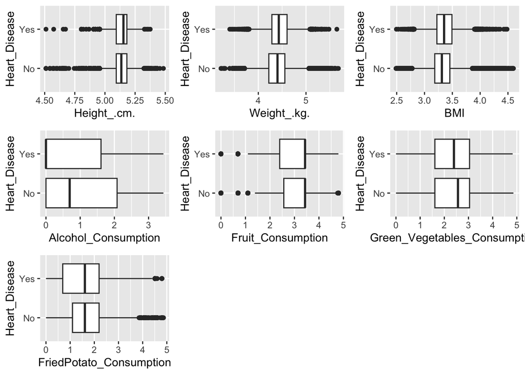

```r
pl1 <- ggplot(data = new_cvd, aes(Height_.cm., Heart_Disease)) +
  geom_boxplot()

pl2 <- ggplot(data = new_cvd, aes(Weight_.kg., Heart_Disease)) +
  geom_boxplot()

pl3 <- ggplot(data = new_cvd, aes(BMI, Heart_Disease)) +
  geom_boxplot()

pl4 <- ggplot(data = new_cvd, aes(Alcohol_Consumption, Heart_Disease)) +
  geom_boxplot()

pl5 <- ggplot(data = new_cvd, aes(Fruit_Consumption, Heart_Disease)) +
  geom_boxplot()

pl6 <- ggplot(data = new_cvd, aes(Green_Vegetables_Consumption, Heart_Disease)) +
  geom_boxplot()

pl7 <- ggplot(data = new_cvd, aes(FriedPotato_Consumption, Heart_Disease)) +
  geom_boxplot()

grid.arrange(pl1,pl2,pl3,pl4,pl5,pl6,pl7)
```

- Density Distributions of Numerical Variables (After Log-Transformation)

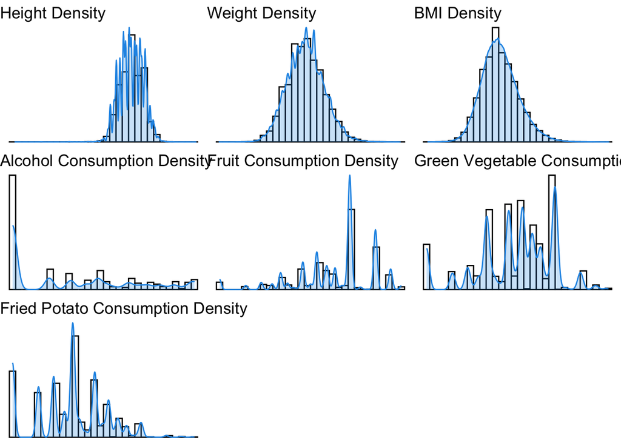

```r
pl1 <- ggplot(data = new_cvd, aes(x = Height_.cm., y = after_stat(density))) +
  geom_histogram(fill = "white", colour = "black") +
  geom_density(color = 4, fill = 4, alpha = 0.25) +
  ggtitle("Height Density") +
  xlab("Height (cm)") + ylab("Density") +
  theme_void()

pl2 <- ggplot(data = new_cvd, aes(x = Weight_.kg., y = after_stat(density))) +
  geom_histogram(fill = "white", colour = "black") +
  geom_density(color = 4, fill = 4, alpha = 0.25) +
  ggtitle("Weight Density") +
  xlab("Weight (kg)") + ylab("Density") +
  theme_void()

pl3 <- ggplot(data = new_cvd, aes(x = BMI, y = after_stat(density))) +
  geom_histogram(fill = "white", colour = "black") +
  geom_density(color = 4, fill = 4, alpha = 0.25) +
  ggtitle("BMI Density") +
  xlab("BMI") + ylab("Density") +
  theme_void()

pl4 <- ggplot(data = new_cvd, aes(x = Alcohol_Consumption, y = after_stat(density))) +
  geom_histogram(fill = "white", colour = "black") +
  geom_density(color = 4, fill = 4, alpha = 0.25) +
  ggtitle("Alcohol Consumption Density") +
  xlab("Number of Days Alcohol was Consumed within Last 30 Days") + ylab("Density") +
  theme_void()

pl5 <- ggplot(data = new_cvd, aes(x = Fruit_Consumption, y = after_stat(density))) +
  geom_histogram(fill = "white", colour = "black") +
  geom_density(color = 4, fill = 4, alpha = 0.25) +
  ggtitle("Fruit Consumption Density") +
  xlab("Fruit Consumption in last 30 days") + ylab("Density") +
  theme_void()

pl6 <- ggplot(data = new_cvd, aes(x = Green_Vegetables_Consumption, y = after_stat(density))) +
  geom_histogram(fill = "white", colour = "black") +
  geom_density(color = 4, fill = 4, alpha = 0.25) +
  ggtitle("Green Vegetable Consumption Density") +
  xlab("Green Vegetable Consumption in last 30 days") + ylab("Density") +
  theme_void()

pl7 <- ggplot(data = new_cvd, aes(x = FriedPotato_Consumption, y = after_stat(density))) +
  geom_histogram(fill = "white", colour = "black") +
  geom_density(color = 4, fill = 4, alpha = 0.25) +
  ggtitle("Fried Potato Consumption Density") +
  xlab("Fried Potato Consumption in last 30 days") + ylab("Density") +
  theme_void()

grid.arrange(pl1,pl2,pl3,pl4,pl5,pl6,pl7)
```

New model with log transformations:

```r
# Heart Disease to int

newmodel1 <- glm(formula = HD_Int ~ . - Heart_Disease, data = new_cvd, family = "binomial")
summary(newmodel1)
```

```
##
## Call:
## glm(formula = HD_Int ~ . - Heart_Disease, family = "binomial",
##     data = new_cvd)
##
## Coefficients:
##                                                     Estimate Std. Error z value
## (Intercept)                                         8.241458  22.299084   0.370
## General_HealthFair                                  1.620707   0.041981  38.605
## General_HealthGood                                  1.042361   0.039922  26.110
## General_HealthPoor                                  2.080274   0.046532  44.706
## General_HealthVery Good                             0.509998   0.040928  12.461
## CheckupNever                                        0.258636   0.179356   1.442
## CheckupWithin the past 2 years                      0.224127   0.074935   2.991
## CheckupWithin the past 5 years                      0.127670   0.088328   1.445
## CheckupWithin the past year                         0.507304   0.068356   7.421
## ExerciseYes                                        -0.008066   0.019007  -0.424
## Skin_CancerYes                                      0.107914   0.022586   4.778
## Other_CancerYes                                     0.044336   0.022233   1.994
## DepressionYes                                       0.226784   0.020808  10.899
## DiabetesNo, pre-diabetes or borderline diabetes     0.133730   0.047601   2.809
## DiabetesYes                                         0.474987   0.019453  24.417
## DiabetesYes, but female told only during pregnancy  0.109719   0.128442   0.854
## ArthritisYes                                        0.243117   0.017752  13.695
## SexMale                                             0.773716   0.024279  31.867
## Age_Category25-29                                   0.314635   0.168407   1.868
## Age_Category30-34                                   0.642072   0.150944   4.254
## Age_Category35-39                                   0.760509   0.144546   5.261
## Age_Category40-44                                   1.091785   0.137771   7.925
## Age_Category45-49                                   1.467499   0.133482  10.994
## Age_Category50-54                                   1.774008   0.130062  13.640
## Age_Category55-59                                   2.102377   0.128216  16.397
## Age_Category60-64                                   2.328093   0.127335  18.283
## Age_Category65-69                                   2.551564   0.127035  20.086
## Age_Category70-74                                   2.790487   0.126960  21.979
## Age_Category75-79                                   3.007278   0.127515  23.584
## Age_Category80+                                     3.254988   0.127293  25.571
## Height_.cm.                                        -3.357538   4.843630  -0.693
## Weight_.kg.                                         1.329745   2.432495   0.547
## BMI                                                -1.241810   2.433065  -0.510
```

[output cut: 39 more lines]

```
## Smoking_HistoryYes                                  < 2e-16 ***
## Alcohol_Consumption                                 < 2e-16 ***
## Fruit_Consumption                                   0.10225
## Green_Vegetables_Consumption                        0.03700 *
## FriedPotato_Consumption                             0.06501 .
## ---
## Signif. codes:  0 '***' 0.001 '**' 0.01 '*' 0.05 '.' 0.1 ' ' 1
##
## (Dispersion parameter for binomial family taken to be 1)
##
##     Null deviance: 102582  on 308773  degrees of freedom
## Residual deviance:  78291  on 308736  degrees of freedom
## AIC: 140671
##
## Number of Fisher Scoring iterations: 8
```

```r
# str(new_cvd)
```

```r
anova <- aov(newmodel1)
summary(anova)
```

```
##                                  Df Sum Sq Mean Sq  F value   Pr(>F)
## General_Health                    4    687  171.65 5497.561  < 2e-16 ***
## Checkup                           4     57   14.26  456.783  < 2e-16 ***
## Exercise                          1      7    6.74  215.940  < 2e-16 ***
## Skin_Cancer                       1     61   61.46 1968.544  < 2e-16 ***
## Other_Cancer                      1     17   17.44  558.621  < 2e-16 ***
## Depression                        1      4    3.94  126.211  < 2e-16 ***
## Diabetes                          3    129   42.94 1375.089  < 2e-16 ***
## Arthritis                         1     51   50.80 1627.111  < 2e-16 ***
## Sex                               1     79   78.67 2519.676  < 2e-16 ***
## Age_Category                     12    268   22.37  716.555  < 2e-16 ***
## Height_.cm.                       1      0    0.35   11.126 0.000851 ***
## Weight_.kg.                       1      0    0.35   11.189 0.000823 ***
## BMI                               1      0    0.01    0.254 0.614297
## Smoking_History                   1     21   21.23  679.991  < 2e-16 ***
## Alcohol_Consumption               1      5    5.05  161.713  < 2e-16 ***
## Fruit_Consumption                 1      0    0.00    0.004 0.947213
## Green_Vegetables_Consumption      1      0    0.34   11.013 0.000905 ***
## FriedPotato_Consumption           1      0    0.00    0.107 0.743751
## Residuals                    308736   9640    0.03
## ---
## Signif. codes:  0 '***' 0.001 '**' 0.01 '*' 0.05 '.' 0.1 ' ' 1
```

```r
vif(newmodel1)
```

```
##                                     GVIF Df GVIF^(1/(2*Df))
## General_Health                  1.323397  4        1.035646
## Checkup                         1.064685  4        1.007866
## Exercise                        1.191087  1        1.091369
## Skin_Cancer                     1.087019  1        1.042602
## Other_Cancer                    1.060991  1        1.030044
## Depression                      1.145421  1        1.070243
## Diabetes                        1.170209  3        1.026543
## Arthritis                       1.140383  1        1.067887
## Sex                             2.095214  1        1.447485
## Age_Category                    1.374702 12        1.013348
## Height_.cm.                  1384.279784  1       37.205911
## Weight_.kg.                  5276.069872  1       72.636560
## BMI                          3990.345739  1       63.169183
## Smoking_History                 1.059146  1        1.029148
## Alcohol_Consumption             1.117056  1        1.056909
## Fruit_Consumption               1.144861  1        1.069982
## Green_Vegetables_Consumption    1.156101  1        1.075221
## FriedPotato_Consumption         1.066637  1        1.032781
```

- By squaring the GVIF^(1/(2*Df)) values, we can conclude that there is a high multicollinearity problem regarding Height, Weight, and BMI.

Binned Residuals of Log Transformed

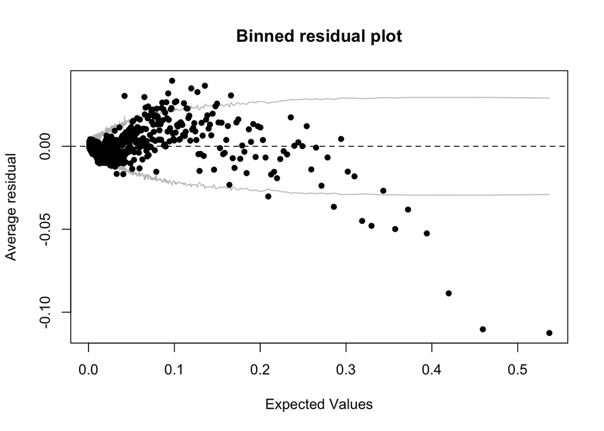

```r
binnedplot(fitted(newmodel1),
           residuals(newmodel1, type = "response"),
           nclass = NULL,
           xlab = "Expected Values",
           ylab = "Average residual",
           main = "Binned residual plot",
           cex.pts = 0.8,
           col.pts = 1,
           col.int = "gray")
```

- Still not performing great in terms of outliers.
- Outliers can be caused by some unknown outside factors.

## Accuracy of Log-Transformed Model

```r
prediction <- ifelse(newmodel1$fitted.values > 0.5, "pos", "neg")

confusion_matrix <- table(cvd$HD_Int, prediction)
rownames(confusion_matrix) <- c("No Heart Disease", "Heart Disease")
colnames(confusion_matrix) <- c("Predicted No Heart Disease", "Predicted Heart Disease")
confusion_matrix
```

```
##                   prediction
##                    Predicted No Heart Disease Predicted Heart Disease
##   No Heart Disease                     283639                     164
##   Heart Disease                         24712                     259
```

```r
accuracy <- sum(diag(confusion_matrix))/sum(confusion_matrix)
accuracy
```

```
## [1] 0.9194362
```

```r
# Area under curve, 1 indicates perfect predictive model
auc(cvd$HD_Int~newmodel1$fitted.values, data = cvd)
```

```
## Area under the curve: 0.8351
```